# Lecture #19

산점도와 상관계수

Junho Ahn

2022-09-08

## 공분산과 상관계수

### 공분산과 상관계수의 사용

- 키와 몸무게가 어느 정도 상관이 있는지, 소득과 저축의 관계는 어떠한지와 같이 두 속성의 연관을 수치로 나타내기 위한 방법으로 공분산이나 상관계수를 사용할 수 있음
- 공분산은 같은 자료라도 측정단위에 따라 달라지므로 주로 상관계수가 사용됨

### 계산 방법 및 성질

**공분산의 계산방법**

- 두 속성 $x$와 $y$에 대한 자료가 $(x_1, y_1),(x_2, y_2), ... , (x_n,y_n)$로 $n$개의 짝으로 얻어진 경우 두 자료의 공분산은 다음과 같이 정의함

$$S_{xy}=\frac{\displaystyle \sum _{i=1}
^n (x_i - \bar x)(y_i - \bar y)}{n-1}=\frac{\displaystyle \sum _{i=1} ^n
x_i y_i - n \bar x \bar y}{n-1}$$

- $x$가 증가(감소)할 때 $y$가 증가(감소)하면 공분산은 양의 값을 가짐
- $x$가 증가(감소)할 때 $y$가 감소(증가)하면 공분산은 음의 값을 가짐

**상관계수의 계산방법**

- 상관계수라고 하면 보통 피어슨(pearson)의 선형상관계수를 말하며, 표본에서 얻은 상관계수는 보통 $\gamma$로 표시함
- 상관계수 $\gamma$는 다음과 같이 정의함

$$\gamma = \frac{Cov(x,y)}{S_x S_y} =
\frac {\displaystyle \sum _{i=1} ^n (x_i - \bar x)(y_i - \bar
y)}{\sqrt{\displaystyle \sum _{i=1} ^n (x_i - \bar
x)^2}\sqrt{\displaystyle \sum _{i=1} ^n (y_i - \bar y)^2}}$$

- 여기서 $S_x$와 $S_y$는 각각 $x$와 $y$의 표준편차

**상관계수 $\gamma$**

- $-1 < \gamma < 1$의 값을 가짐
- $x$가 증가(감소)할 때 $y$가 증가(감소)하면 상관계수는 양의 값을 가지며, $x$가 증가(감소)할 때 $y$가 감소(증가)하면 상관계수는 음의 값을 가짐
- 상관이 높을수록 상관계수의 절댓값이 1에 가까워지면 $(x_1, y_1),(x_2, y_2), ... , (x_n,y_n)$의 모든 점이 한 직선위에 존재하면 상관계수는 1또는 -1의 값을 가짐
- 두 변수 독립이면 표본에서 얻은 상관계수 $\gamma$는 0에 가까운 값을 가지며, 역은 성립하지 않음. 즉 상관계수가 0(또는 0에 가까운 값)이라고 하더라도 두 변수는 독립이 아닐 수 있음

### R-언어의 함수

상관계수 및 공분산은 각각 `cor()`, `cov()`함수를 사용하여 얻을 수 있음

(단위에 따른 공분산과 상관계수) 공분산은 단위에 따라 달라지나 상관계수는 측정단위에 무관함을 확인하기 위하여 같은 자료 다른 단위인 5명의 학생의 키와 몸무게의 공분산과 상관계수 확인

```r
htcm <- c(170, 179, 174, 167, 175)
wtkg <- c(62, 67, 70, 60, 72)
```

```r
htin <- htcm*0.394
wtlb <- wtkg*2.2
```

같은 자료에서 다른 단위를 사용한 경우 공분산 계산 결과

```r
cov(htcm, wtkg)
```

```
## [1] 17.5
```

```r
cov(htin, wtlb)
```

```
## [1] 15.169
```

같은 방법으로 상관계수 계산

```r
cor(htcm, wtkg)
```

```
## [1] 0.7373406
```

```r
cor(htin, wtlb)
```

```
## [1] 0.7373406
```

공분산은 다르지만 상관계수의 값은 두 단뒤 모두에 대해서 같은 값을 얻음

(결측치가 포함된 자료의 처리) 다음의 자료는 결측치를 포함한 자료이다.

```r
x1 <- c(1, NA, 2, 3, NA, 4, 5, NA, 6, 7, NA, 8, 9, 10, 11)
x2 <- c(NA, 1, 2, NA, 3, 4, NA, 6, 7, NA, 8, 9, 9, 11, 12)
x3 <- c(1, 2, NA, 3, 4, NA, 5, 6, NA, 7, 8, NA, 9, 10, 11)
x <- cbind(x1, x2, x3)
t(x)
```

```
##    [,1] [,2] [,3] [,4] [,5] [,6] [,7] [,8] [,9] [,10] [,11] [,12] [,13] [,14]
## x1    1   NA    2    3   NA    4    5   NA    6     7    NA     8     9    10
## x2   NA    1    2   NA    3    4   NA    6    7    NA     8     9     9    11
## x3    1    2   NA    3    4   NA    5    6   NA     7     8    NA     9    10
##    [,15]
## x1    11
## x2    12
## x3    11
```

```r
cor(x, use = "everything") # 하나라도 결측치가 있으면 NA 처리
```

```
##    x1 x2 x3
## x1  1 NA NA
## x2 NA  1 NA
## x3 NA NA  1
```

```r
cor(x, use = "all.obs") # 하나라도 결측치이면 에러메시지

# Error in cor(x, use = "all.obs") : missing observations in cov/cor
```

```r
cor(x, use="pairwise.complete.obs") # 각(x1,x2), (x1,x3), (x2,x3) pair들끼리 계산
```

```
##           x1        x2        x3
## x1 1.0000000 0.9931966 1.0000000
## x2 0.9931966 1.0000000 0.9973115
## x3 1.0000000 0.9973115 1.0000000
```

```r
cor(x, use = "complete") # 모든 x1, x2, x3가 NA가 아닌 경우만 계산
```

```
##           x1        x2        x3
## x1 1.0000000 0.9819805 1.0000000
## x2 0.9819805 1.0000000 0.9819805
## x3 1.0000000 0.9819805 1.0000000
```

```r
cor(x, use = "na.or.complete") # 모든 x1, x2, x3가 NA가 아닌 경우만 계산
```

```
##           x1        x2        x3
## x1 1.0000000 0.9819805 1.0000000
## x2 0.9819805 1.0000000 0.9819805
## x3 1.0000000 0.9819805 1.0000000
```

```r
cor(x[1:12,], use = "complete")

# Error in cor(x[1:12, ], use = "complete") : no complete element pairs
```

```r
cor(x[1:12,], use = "na.or.complete")
```

```
##    x1 x2 x3
## x1 NA NA NA
## x2 NA NA NA
## x3 NA NA NA
```

(예시) BMI자료에서 키와 몸무게의 상관계수 및 공분산을 계산해보고 이 결과를 상관계수 공식으로 계산한 결과와 비교해보자.

```r
BMI <- read.table("./bmi.txt",
                    col.names = c("height","weight","year","religion","gender","marriage"))
```

키와 몸무게의 공분산

```r
cov(BMI$height, BMI$weight)
```

```
## [1] 25.42062
```

키와 몸무게의 상관계수

```r
cor(BMI$height, BMI$weight)
```

```
## [1] 0.6473976
```

상관계수의 공식적용

```r
cov(BMI$height,BMI$weight)/(sd(BMI$height)*sd(BMI$weight))
```

```
## [1] 0.6473976
```

(독립인 경우의 상관계수) 표준정규분포로부터 100개씩의 난수를 세 번 얻어 이를 100X3행렬에 저장하여 이의 상관계수를 얻어보자.

```r
x <- cbind(rnorm(100),rnorm(100),rnorm(100))
```

```r
cor(x)
```

```
##            [,1]       [,2]       [,3]
## [1,] 1.00000000 0.08553143 0.00976079
## [2,] 0.08553143 1.00000000 0.01659195
## [3,] 0.00976079 0.01659195 1.00000000
```

## 상관계수에 대한 이해

### 변수와 상관계수와의 관계

두 변수가 독립이면 상관계수가 0 (자료에서는 0에 가까운 값)이지만 상관계수가 0이라고 해서 두 변수가 독립이라고 할 수 없는 경우가 많음  
이 경우는 두 변수의 관계가 직선이 아닌 관계에 있는 경우에 많이 발생함

### 상관게수는 0이지만 두 변수 사이에 관계가 있는 경우

(자료) 다음과 같이 x와 y를 정의하고 두 변수 사이의 상관계수를 계산해보고 산점도로 두 변수 사이의 관계를 확인해보자.

```r
x <- seq(-1, 1, by = 0.05)
y <- x^2
cor(x,y)
```

```
## [1] 3.073171e-16
```

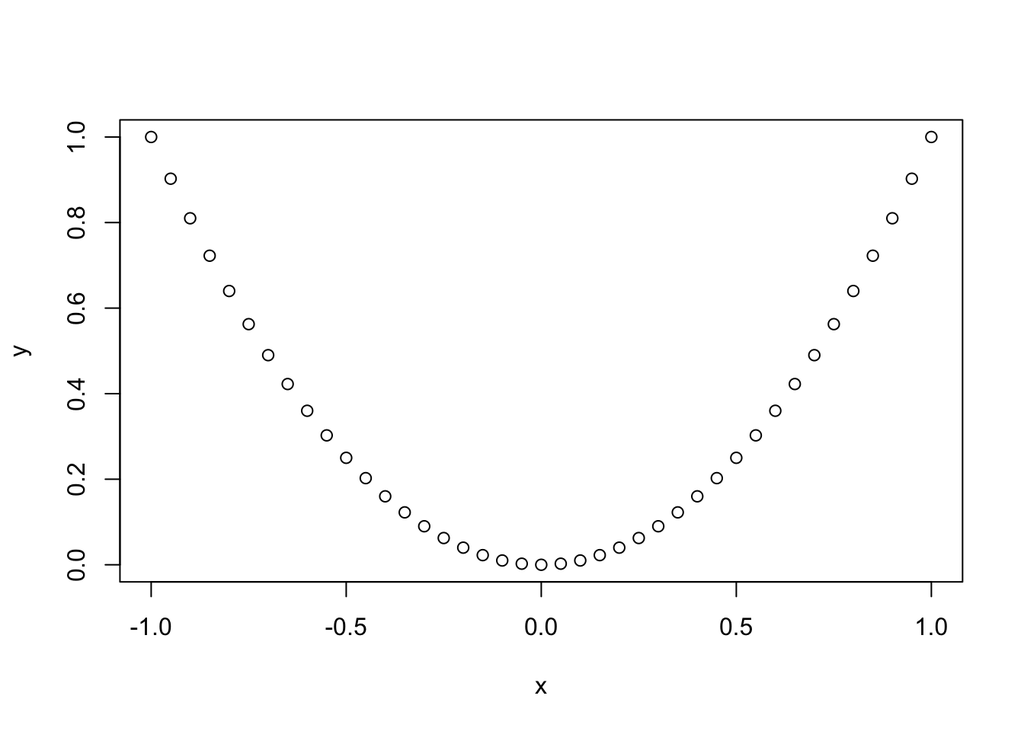

```r
plot(x,y)
```

- $x$는 -1에서 1사이의 값이고, $y=x^2$으로 포물선을 그리는 관계가 있음
- $x$와 $y$사이 상관계수는 0임
- 위 산점도에서 보는 것과 같이 $x$가 증가하면 $y$가 감소하다가 증가하는 패턴이 뚜렷하게 보임

**피어슨(Pearson)선형 상관계수**

- 선형(linear)은 ’직선’라는 의미로 이 상관계수는 직선관계는 수치로 잘 표현할 수 있지만 직선이 아닌 관계에 대해서는 잘 표현할 수 없음을 말함
- 상관에 대한 분석에서는 상관계수만 보면 잘못된 판단을 내릴 수 있으므로 반드시 산점도를 확인하여 직선 이외의 관계가 있는지 확인할 필요가 있음